# Midterm Project - Hawaiin Survey Data

19/10/2019

## Data Set

- For this project, we are using the Hawaiin Health Survey data.
- Our ‘modeling team’ wanted a tidy data set to use for logistic regression, to analyze the observed risks of being diagnosed with diabetes, in relation to a number of different predictors

## Steps Taken

The steps taken to prepare this data for analysis was as follows:  
1. Access raw survey data file  
2. Ensure data was of sufficient volume and uniqueness  
3. Extract variables of interest (diabetes and predictors)  
4. Clean these multiple data subsets  
5. Bring subsets together to form new Tidy data set  
6. EDA on Tidy data, preparing for further statisical analysis & modeling

## Data Volume & Uniqueness Check

- Once the raw data was extracted, counts of NA values for each variable, as well as uniqueness of responses were needed to determine what variables were sufficient for analysis.
- Data generated (preview subset):

```
##  NACount UniqueAnswers
##     1500             5
##        0             4
##     2063             4
##     2063             3
##     2063             3
##        0             4
```

## Extracting Variables

Variables of interest for this analysis were as follows:

- Outcome: Diabetes (binary (0,1))
- Predictor: Height(in) (categorical)
- Predictor: Weight(lbs) (categorical)
- Predictor: BMI (categorical)
- Predictor: Alcohol Consumption (categorical)
- Predictor: Sick Days Taken Annually (categorical)
- Predictor: Sleep Hours per Night (categorical)
- Predictor: Joint Pain (binary(1,2))

## Cleaning the data

The different aspects required to clean these extracted variables were as follows:

- Recode missing values from each variable (eg: 997, 998, 999, etc.) to NA’s
- Recode the diabetes variable categorization to a binary set of (0,1) (assumptions that were made are documented in the report)
- Settle any other abnormalities in the predictors variable data (documented in report)
- Rename column variable names for easier interpretation
- Remove all final observation rows containing any NA values

## Tidy Data

From here, we generated a new clean data set as shown: (header preview)

```
##   Diabetes Height_(in) Weight_(lbs) BMI Alcohol_Consum Sick_Days_General
## 1        0          71          240   4              6                 0
## 2        1          64          160   3              1                 1
## 3        0          63          115   2              6                 0
## 5        0          69          170   3              5                 0
## 7        1          63          190   4              2                 0
## 9        0          65          189   4              2                10
##   Hours_Sleep_Night Joint_Pain
## 1                 4          1
## 2                 8          1
## 3                 6          2
## 5                 6          2
## 7                 6          1
## 9                 6          1
```

## EDA

Once our tidy data set was generated, we then began to run EDA on diabetes data, to try and see what patterns or certain observations would arise.

We chose to run multiple histograms on a number of the predictor variables (excluding physical attributes height weight), to look at the distributions of survey response values for each. Since each predictor variable organized their data in a categorical sense, we will also show corresponding categorization tables to each visual.

## Alcohol

Alcohol Categorization

| Category | Number |
| --- | --- |
| Lifetime abstainer | 1 |
| Former infrequent | 2 |
| Former regular | 3 |
| Former, unknown frequency | 4 |
| Current infrequent | 5 |
| Current light | 6 |
| Current moderate | 7 |
| Current heavier | 8 |
| Current drinker, frequency/level unknown | 9 |

## Alcohol

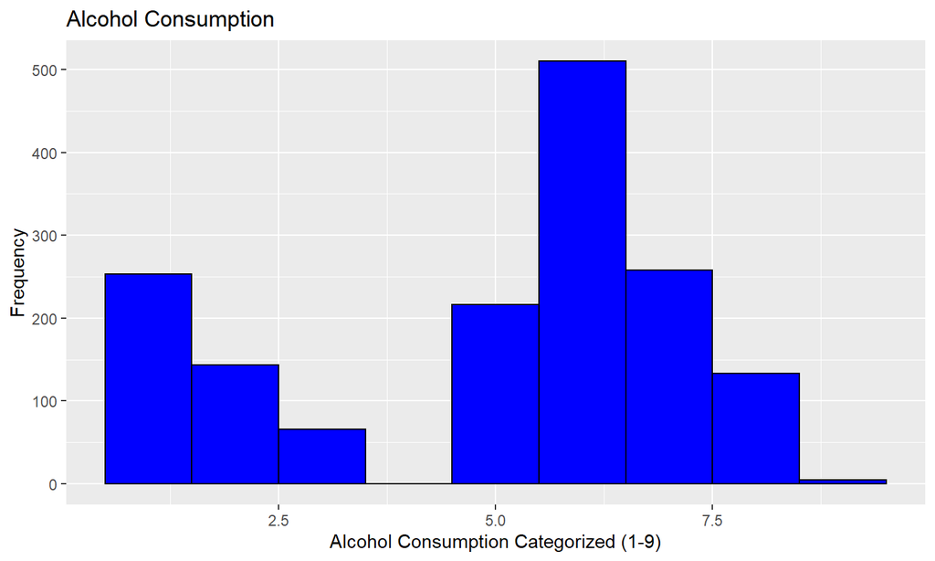

- Here we essentially have a split between individuals who are former drinkers or abstainers, and a larger subset who are current drinkers, with most identifying on the ‘light’ side, while still a significant amount on the moderate-heavy side.

## BMI

BMI Categorization

| Category | Number |
| --- | --- |
| Underwieght | 1 |
| Healthy Weight | 2 |
| Overweight | 3 |
| Obese | 4 |

## BMI

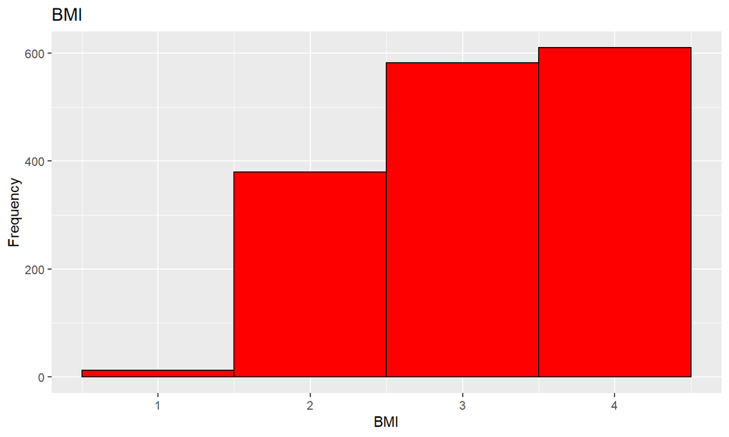

- From here we can see that there is a significant skew of these individuals either overweight, or obese. This could suggest we’re looking at quite a few individuals in this data set with less than optimal health.

## Count of Sick Days Taken per Year

Sick Days Categorization

| Category | Number |
| --- | --- |
| 0-18 days | 0-18 |
| 19 or more days | 19 |

## Count of Sick Days Taken per Year

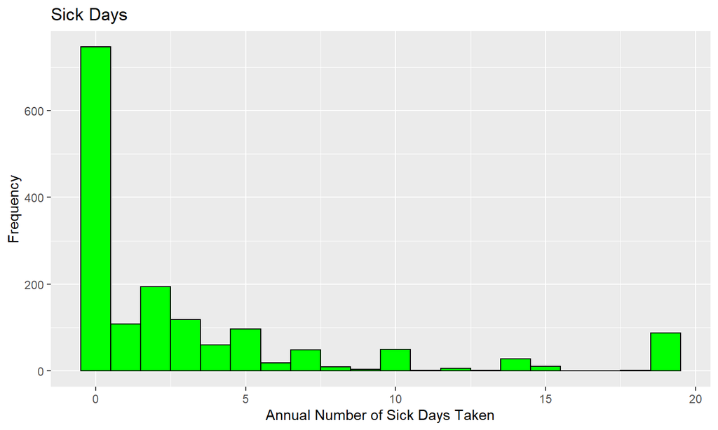

- We can see that most individuals missed little to no time from work due to illnesses. There are a significant few between 2-5 sick days taken, and then a significant outlier subset of a few people who claim they missed more than 15 days.

## Sleep Hours per Night

Sleep Amounts Categorization

| Category | Number |
| --- | --- |
| 1-3 hours | 3 |
| 4-11 hours | 4-11 |
| 12 or more hours | 12 |

## Sleep Hours per Night

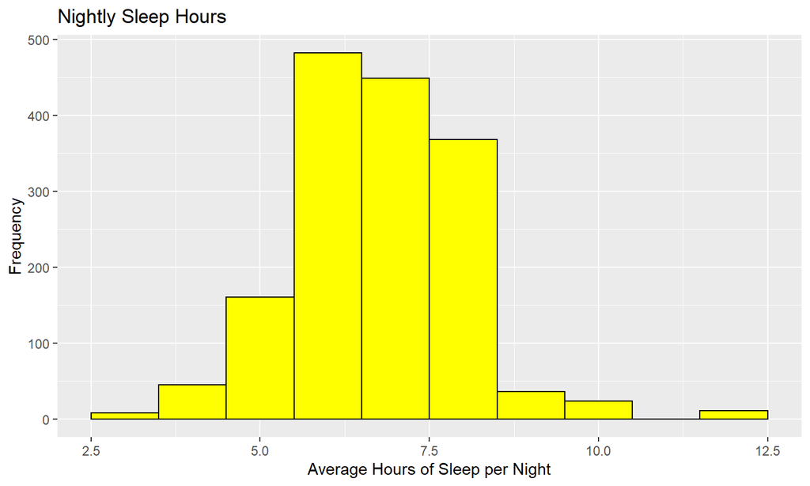

- From here, we can see that most average at just about 6 hours of sleep a night, with the majority of individuals hovering between 5-8 hours.

## Concluding/Next Steps

From here, the ‘modeling team’ can take this cleaned and explored data set to start analysis, with the main goal of creating a logistic regression model to analyze the risks of diabetes diagnosis.